# Environmental Data Preparation

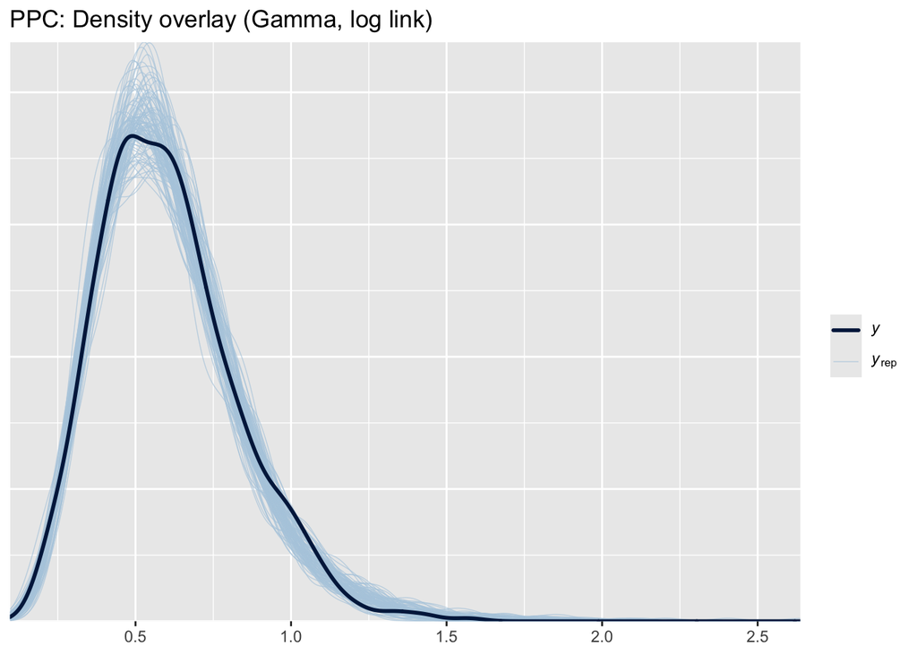

```r
suppressPackageStartupMessages({
  library(brms)
  library(bayesplot)
  library(ggplot2)
})

# --- Load model ---
final_main <- readRDS("models/final_main.rds")

# --- Posterior predictive checks ---
# Density overlay
pp_check(final_main, type = "dens_overlay", ndraws = 100) +
  ggtitle("PPC: Density overlay (Gamma, log link)")
```

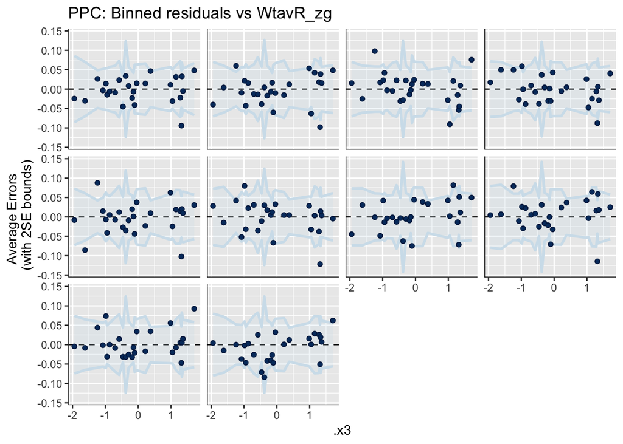

```r
# Residuals binned by predictor
pp_check(final_main, type = "error_binned", x = "WtavR_zg") +
  ggtitle("PPC: Binned residuals vs WtavR_zg")
```

```
## Some PIT values larger than 1! Largest:  1
## Rounding PIT > 1 to 1.
```

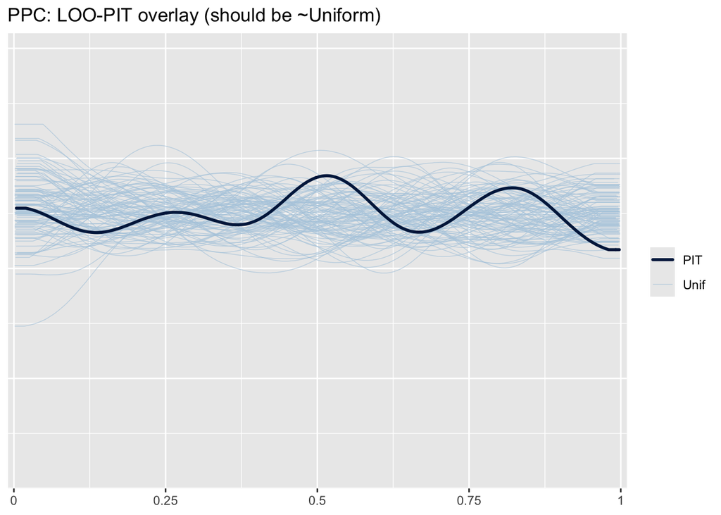

```r
# LOO-PIT overlay (calibration)
pp_check(final_main, type = "loo_pit_overlay", ndraws = 200) +
  ggtitle("PPC: LOO-PIT overlay (should be ~Uniform)")
```

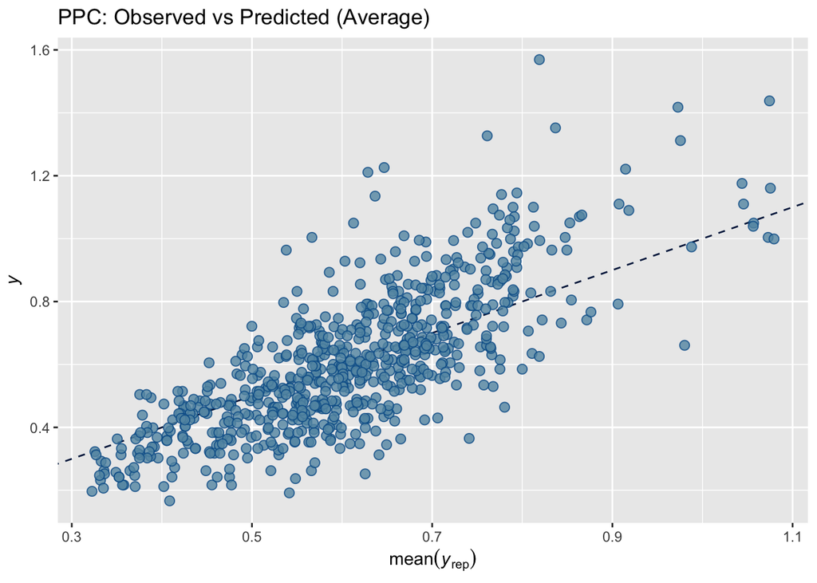

```r
# Observed vs predicted means
pp_check(final_main, type = "scatter_avg") +
  ggtitle("PPC: Observed vs Predicted (Average)")
```

### 1.2.5 Variance decomposition

Lets look at our model R squared values:

| Model | Conditional R² | 95% CI (Conditional) | Marginal R² | 95% CI (Marginal) |
| --- | --- | --- | --- | --- |
| **final_main** | 0.465 | [0.385, 0.530] | 0.090 | [0.016, 0.186] |

When we consider our Bayesian R squared values we can see the overall model explains nearly half (around 46 %) of the variation in the data, where the fixed effects explain about 9% of this. This means that the vast majority of variation in linear extension is within individual and between individual colonies (i.e. there is lots of individual and intra-individual variation in growth). BRMS models have nice properties where we can easily break down the amount of variation that each model term explains (relative to the 46 % of variation the model explains).

```r
# ============================================================
# Variance decomposition of conditional R² for brms model: final_main
# - Uses fixef() draws + your data (no update/compile)
# - Fixed mains & interactions apportioned -> Marginal R²
# - Random effects split -> (Conditional R² - Marginal R²)
# - Saves a PDF barplot
# ============================================================

suppressPackageStartupMessages({
  library(brms)
  library(dplyr)
  library(posterior)
  library(ggplot2)
})

# -----------------------------
# CONFIG
# -----------------------------
R2_marg <- 0.090   # your marginal R² (fixed)
R2_cond <- 0.465   # your conditional R² (fixed + random)

if (!inherits(final_main, "brmsfit")) stop("Object 'final_main' is not a brmsfit.")
dat <- final_main$data
if (!is.data.frame(dat)) stop("final_main$data is not a data.frame.")
R2_rand <- max(0, R2_cond - R2_marg)

# -----------------------------
# 1) Fixed-effect draws and design matrix
# -----------------------------
B <- as.matrix(brms::fixef(final_main, summary = FALSE))
coef_names <- colnames(B)
is_cat <- vapply(dat, function(x) is.factor(x) || is.character(x), logical(1))
cat_vars <- names(dat)[is_cat]

build_col_for_term <- function(term) {
  if (term == "Intercept") return(rep(1, nrow(dat)))
  make_base <- function(atom) {
    if (atom %in% names(dat) && !(is_cat[atom])) return(as.numeric(dat[[atom]]))
    for (fv in cat_vars) {
      if (startsWith(atom, fv)) {
        lev <- sub(paste0("^", fv), "", atom)
        if (lev == "") break
        x <- dat[[fv]]
        if (is.character(x)) {
          return(as.numeric(x == lev))
        } else if (is.factor(x)) {
          return(as.numeric(x == lev))
        }
      }
    }
    if (atom %in% names(dat)) return(as.numeric(dat[[atom]]))
    stop("Could not construct column for coefficient atom: ", atom)
  }
  if (grepl(":", term, fixed = TRUE)) {
    parts <- strsplit(term, ":", fixed = TRUE)[[1]]
    cols <- lapply(parts, make_base)
    Reduce(`*`, cols)
  } else {
    make_base(term)
  }
}

X <- vapply(coef_names, build_col_for_term, numeric(nrow(dat)))
X <- as.matrix(X)
colnames(X) <- coef_names

# -----------------------------
# 2) Eta draws helper
# -----------------------------
eta_from_cols <- function(cols_to_keep) {
  idx <- which(coef_names %in% c("Intercept", cols_to_keep))
  Bk <- B[, idx, drop = FALSE]
  Xk <- X[, idx, drop = FALSE]
  Bk %*% t(Xk)
}

eta_full <- eta_from_cols(coef_names)
var_full_draw <- apply(eta_full, 1, function(v) var(v[is.finite(v)]))
var_full_draw <- var_full_draw[is.finite(var_full_draw)]

# -----------------------------
# 3) Conceptual terms
# -----------------------------
main_terms <- c("WtavR_zg", "winSlope_c", "gulf", "Bheight_c")
int_terms  <- c("winSlope_c:Bheight_c", "WtavR_zg:gulf")
analysis_terms <- c(main_terms, int_terms)

map_term_to_coefs <- function(term) {
  if (term == "gulf") {
    gulf_cols <- grep("^gulf", coef_names, value = TRUE)
    int_with_gulf <- grep(paste0("(^|:)", paste(gulf_cols, collapse = "|"), "(:|$)"),
                          coef_names, value = TRUE)
    unique(c(gulf_cols, int_with_gulf))
  } else if (grepl(":", term, fixed = TRUE)) {
    parts <- strsplit(term, ":", fixed = TRUE)[[1]]
    parts_rx <- sapply(parts, function(p) if (p == "gulf") "gulf[^:]+" else p)
    rx <- paste0("(^|:)", parts_rx[1], ":", parts_rx[2], "(:|$)|(^|:)",
                 parts_rx[2], ":", parts_rx[1], "(:|$)")
    grep(rx, coef_names, value = TRUE, perl = TRUE)
  } else {
    grep(paste0("(^|:)", term, "(:|$)"), coef_names, value = TRUE)
  }
}

drop_sets <- lapply(analysis_terms, map_term_to_coefs)
names(drop_sets) <- analysis_terms

# -----------------------------
# 4) Fixed-effect contributions
# -----------------------------
fixed_contrib <- lapply(seq_along(analysis_terms), function(i) {
  term <- analysis_terms[i]
  drop_cols <- unique(drop_sets[[i]])
  keep_cols <- setdiff(coef_names, drop_cols)
  eta_keep <- eta_from_cols(keep_cols)
  var_keep_draw <- apply(eta_keep, 1, function(v) var(v[is.finite(v)]))
  var_keep_draw <- var_keep_draw[is.finite(var_keep_draw)]
  L <- min(length(var_full_draw), length(var_keep_draw))
  contrib_draw <- pmax(0, var_full_draw[seq_len(L)] - var_keep_draw[seq_len(L)])
  data.frame(
    Term = term,
    Var_contrib_mean = mean(contrib_draw),
    Var_contrib_sd   = sd(contrib_draw),
    n_draws          = length(contrib_draw)
  )
}) %>% bind_rows()

sum_fixed <- sum(fixed_contrib$Var_contrib_mean)
fixed_contrib <- fixed_contrib %>%
  mutate(
    within_fixed_share = Var_contrib_mean / sum_fixed,
    within_fixed_se    = (Var_contrib_sd / sqrt(pmax(1, n_draws))) / sum_fixed,
    R2_share           = within_fixed_share * R2_marg,
    Type               = "Fixed"
  ) %>%
  select(Term, Type, R2_share, within_fixed_share, within_fixed_se)

# -----------------------------
# 4b) Credible intervals for fixed effects
# -----------------------------
fixed_contrib_draws <- list()
for (i in seq_along(analysis_terms)) {
  term <- analysis_terms[i]
  drop_cols <- unique(drop_sets[[i]])
  keep_cols <- setdiff(coef_names, drop_cols)
  eta_keep <- eta_from_cols(keep_cols)
  var_keep_draw <- apply(eta_keep, 1, function(v) var(v[is.finite(v)]))
  var_keep_draw <- var_keep_draw[is.finite(var_keep_draw)]
  L <- min(length(var_full_draw), length(var_keep_draw))
  contrib_draw <- pmax(0, var_full_draw[seq_len(L)] - var_keep_draw[seq_len(L)])
  fixed_contrib_draws[[term]] <- contrib_draw
}

L_fixed <- min(vapply(fixed_contrib_draws, length, 1L))
fixed_mat <- sapply(fixed_contrib_draws, function(v) v[seq_len(L_fixed)])
row_sums <- rowSums(fixed_mat)
row_sums[row_sums == 0] <- NA_real_
fixed_R2_draws <- (fixed_mat / row_sums) * R2_marg

quant <- function(x) quantile(x, probs = c(0.025, 0.5, 0.975), na.rm = TRUE)
fixed_ci <- apply(fixed_R2_draws, 2, quant)
fixed_ci_df <- data.frame(
  Term   = colnames(fixed_R2_draws),
  Type   = "Fixed",
  R2_low = fixed_ci[1, ],
  R2_med = fixed_ci[2, ],
  R2_hi  = fixed_ci[3, ],
  row.names = NULL
)

# -----------------------------
# 5) Random-effects intervals
# -----------------------------
draws_df <- as_draws_df(final_main)
sd_names <- grep("^sd_", colnames(draws_df), value = TRUE)
nm_colony      <- grep("^sd_colony__Intercept$", sd_names, value = TRUE)
nm_colony_year <- grep("^sd_colony[\\.:]year__Intercept$", sd_names, value = TRUE, perl = TRUE)

if (length(nm_colony) == 1L && length(nm_colony_year) == 1L) {
  v_colony_draw      <- as.numeric(draws_df[[nm_colony]])^2
  v_colony_year_draw <- as.numeric(draws_df[[nm_colony_year]])^2
  vsum <- v_colony_draw + v_colony_year_draw
  vsum[vsum == 0] <- NA_real_
  rand_R2_colony      <- (v_colony_draw / vsum)      * (R2_cond - R2_marg)
  rand_R2_colony_year <- (v_colony_year_draw / vsum) * (R2_cond - R2_marg)
  rc <- quant(rand_R2_colony)
  rcy <- quant(rand_R2_colony_year)
  rand_ci_df <- rbind(
    data.frame(Term = "RE: colony (Intercept)",      Type = "Random",
               R2_low = rc[1], R2_med = rc[2], R2_hi = rc[3]),
    data.frame(Term = "RE: colony:year (Intercept)", Type = "Random",
               R2_low = rcy[1], R2_med = rcy[2], R2_hi = rcy[3])
  )
} else {
  R2_rand <- max(0, R2_cond - R2_marg)
  rand_ci_df <- data.frame(
    Term = "Random effects (combined)", Type = "Random",
    R2_low = R2_rand, R2_med = R2_rand, R2_hi = R2_rand
  )
}

# -----------------------------
# 6) Combine + plot
# -----------------------------
final_ci_tbl <- bind_rows(fixed_ci_df, rand_ci_df) %>%
  arrange(desc(R2_med))

print(final_ci_tbl, row.names = FALSE)
```

```
##                         Term   Type       R2_low      R2_med      R2_hi
##       RE: colony (Intercept) Random 0.1928839040 0.260570414 0.32201503
##  RE: colony:year (Intercept) Random 0.0529849689 0.114429586 0.18211610
##                         gulf  Fixed 0.0000000000 0.026368551 0.07018799
##                     WtavR_zg  Fixed 0.0000000000 0.024484238 0.05405066
##                WtavR_zg:gulf  Fixed 0.0000000000 0.022331769 0.04032404
##                    Bheight_c  Fixed 0.0006283567 0.005985761 0.03435089
##         winSlope_c:Bheight_c  Fixed 0.0002551683 0.004702823 0.02643231
##                   winSlope_c  Fixed 0.0000000000 0.004560584 0.02785395
```

```r
cat("Check (medians) sum to ~conditional R²:",
    sum(final_ci_tbl$R2_med), "target =", R2_cond, "\n")
```

```
## Check (medians) sum to ~conditional R²: 0.4634337 target = 0.465
```

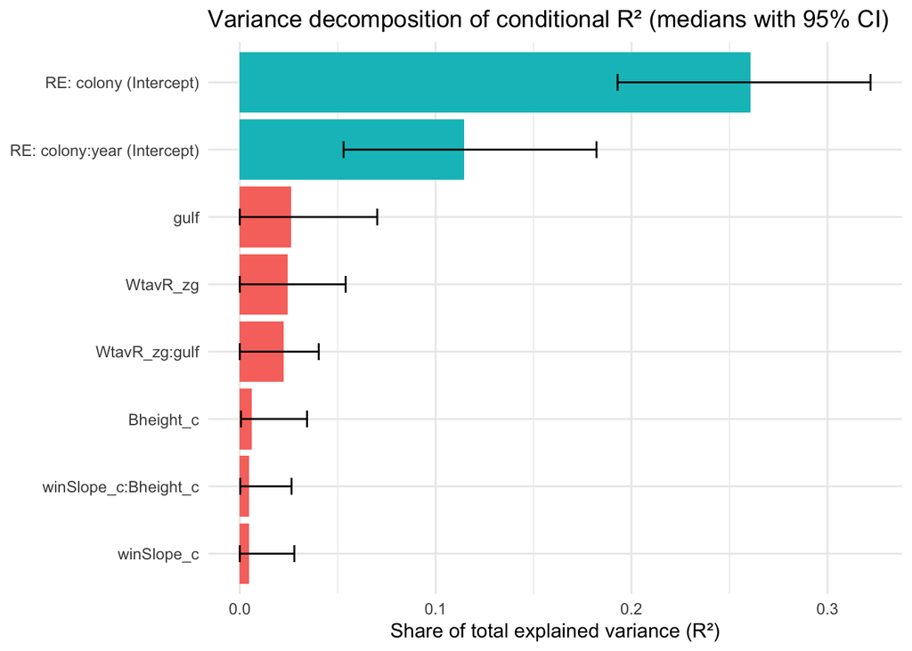

```r
ggplot(final_ci_tbl,
       aes(x = reorder(Term, R2_med), y = R2_med, fill = Type)) +
  geom_col() +
  geom_errorbar(aes(ymin = R2_low, ymax = R2_hi), width = 0.25) +
  coord_flip() +
  labs(x = NULL, y = "Share of total explained variance (R²)",
       title = "Variance decomposition of conditional R² (medians with 95% CI)") +
  theme_minimal(base_size = 11) +
  guides(fill = "none")
```

Above we decomposed the model’s total explained variance (conditional R²) into contributions from each fixed effect and random effect, showing how much each term explains of the overall fitted variation. We see that random variation in growth between individual colonies comprises most of the variability that the model explains. We also see that how colonies within each gulf respond to average winter temperature in the coldest period of the year is more important than how they respond to the rate of temperature change between winter and summer in terms of explained variability.

### 1.2.6 Model plots and interpretation

We can make some basic conditional effect plots before diving a bit deeper. These plots represent the population level effects (i.e. ignore random effects) of fixed effects and their interactions. Although the models were fit on scaled and standardized data, we will visualise them on the original scale of the variables. When trying to plot the winter-rate-of-temp-change: colony height interaction, we will plot the predicted response of the 10th, 50th, and 90th percentile of colony heights.

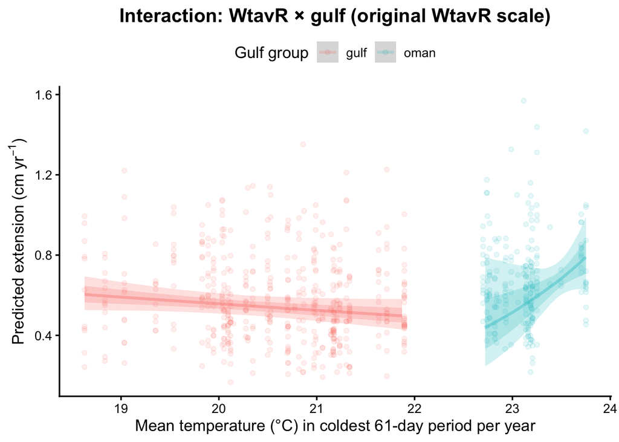

```r
library(dplyr)
library(tidyr)
library(tidybayes)
library(ggplot2)

# 1) Per-gulf summary: mean, sd, min, max (force dplyr versions)
stats_WtavR <- testex %>%
  dplyr::mutate(gulf = as.character(gulf)) %>%
  dplyr::group_by(gulf) %>%
  dplyr::summarise(
    mean_W = mean(WtavR, na.rm = TRUE),
    sd_W   = sd(WtavR,   na.rm = TRUE),
    min_W  = min(WtavR,  na.rm = TRUE),
    max_W  = max(WtavR,  na.rm = TRUE)
  ) %>%
  dplyr::ungroup()

# 2) Build a common fine grid, then clip per-gulf to observed ranges
gulf_levels <- sort(unique(testex$gulf))
new_WtavR <- seq(min(testex$WtavR, na.rm = TRUE),
                 max(testex$WtavR, na.rm = TRUE),
                 length.out = 200)

nd <- tidyr::crossing(
  WtavR = new_WtavR,
  gulf  = gulf_levels
) %>%
  dplyr::left_join(stats_WtavR, by = "gulf") %>%
  dplyr::filter(WtavR >= min_W, WtavR <= max_W) %>%
  dplyr::mutate(
    WtavR_zg  = (WtavR - mean_W) / sd_W,
    winSlope_c = 0,
    Bheight_c  = 0
  )

# 3) Predict (population-level)
nd_pred <- nd %>%
  tidybayes::add_epred_draws(final_main, re_formula = NA)

## The plot
library(ggplot2)
library(tidybayes)
library(dplyr)

ggplot2::ggplot() +
  # 1️⃣ Raw data (semi-transparent points, coloured by group)
  geom_point(
    data = testex,
    aes(x = WtavR, y = extension, color = gulf),
    alpha = 0.10, size = 1.5
  ) +

  # 2️⃣ Model predictions with credible intervals
  tidybayes::stat_lineribbon(
    data = nd_pred,
    aes(x = WtavR, y = .epred, color = gulf, fill = gulf),
    .width    = c(0.95, 0.66),
    .point    = "mean",      # single best-fit line
    alpha     = 0.20,        # transparency of ribbons
    linewidth = 1.1
  ) +

  # 3️⃣ Labels and theme
  labs(
    x = "Mean temperature (°C) in coldest 61-day period per year",
    y = expression(paste("Predicted extension (cm ", yr^{-1}, ")")),
    color = "Gulf group",
    fill  = "Gulf group",
    title = "Interaction: WtavR × gulf (original WtavR scale)"
  ) +

  theme_classic(base_size = 13) +
  theme(
    legend.position = "top",
    plot.title = element_text(face = "bold", hjust = 0.5)
  )
```

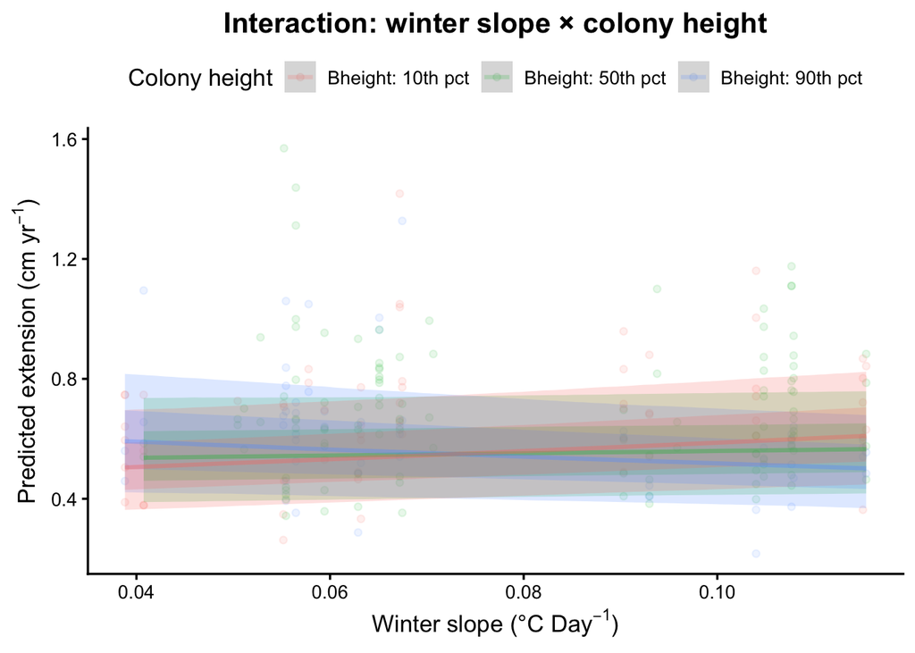

```r
##### And for winter slope and colony size:

library(dplyr)
library(tidyr)
library(tidybayes)
library(ggplot2)

## --- Settings / summaries ---
gulf_ref <- "oman"  # change to "gulf" if you prefer that group

mu_winSlope <- mean(testex$winSlope, na.rm = TRUE)
mu_Bheight  <- mean(testex$Bheight,  na.rm = TRUE)

# Quantiles for Bheight (representative line levels)
bh_q <- quantile(testex$Bheight, probs = c(0.10, 0.50, 0.90), na.rm = TRUE)
q10 <- as.numeric(bh_q[1]); q50 <- as.numeric(bh_q[2]); q90 <- as.numeric(bh_q[3])

# Midpoints for non-overlapping bands
b1 <- (q10 + q50) / 2
b2 <- (q50 + q90) / 2

# Assign observations to bands
test_band <- testex %>%
  dplyr::filter(gulf == gulf_ref) %>%
  dplyr::mutate(
    Bheight_band = cut(
      Bheight,
      breaks = c(-Inf, b1, b2, Inf),
      labels = c("Bheight: 10th pct", "Bheight: 50th pct", "Bheight: 90th pct"),
      right  = TRUE
    )
  ) %>%
  dplyr::filter(!is.na(Bheight_band))

# Observed winSlope ranges per band
band_ranges <- test_band %>%
  dplyr::group_by(Bheight_band) %>%
  dplyr::summarise(
    min_win = min(winSlope, na.rm = TRUE),
    max_win = max(winSlope, na.rm = TRUE),
    .groups = "drop"
  )

# Representative Bheight values for the lines
bh_rep <- dplyr::tibble(
  Bheight_band = factor(
    c("Bheight: 10th pct","Bheight: 50th pct","Bheight: 90th pct"),
    levels = c("Bheight: 10th pct","Bheight: 50th pct","Bheight: 90th pct")
  ),
  Bheight = c(q10, q50, q90)
)

# Band-specific prediction grids (only within observed winSlope ranges)
nd2 <- band_ranges %>%
  dplyr::left_join(bh_rep, by = "Bheight_band") %>%
  dplyr::rowwise() %>%
  dplyr::mutate(winSlope = list(seq(min_win, max_win, length.out = 200))) %>%
  tidyr::unnest(winSlope) %>%
  dplyr::ungroup() %>%
  dplyr::mutate(
    winSlope_c = winSlope - mu_winSlope,
    Bheight_c  = Bheight  - mu_Bheight,
    gulf       = gulf_ref,
    WtavR_zg   = 0
  )

# Posterior expected means (population-level)
nd2_pred <- nd2 %>%
  tidybayes::add_epred_draws(final_main, re_formula = NA)

## --- Plot (same style as WtavR × gulf) ---
ggplot() +
  # Raw data points (transparent)
  ggplot2::geom_point(
    data = test_band,
    ggplot2::aes(x = winSlope, y = extension, color = Bheight_band),
    alpha = 0.10, size = 1.5
  ) +
  # Model predictions (no extrapolation)
  tidybayes::stat_lineribbon(
    data = nd2_pred,
    ggplot2::aes(x = winSlope, y = .epred, color = Bheight_band, fill = Bheight_band),
    .width    = c(0.95, 0.66),
    .point    = "mean",
    alpha     = 0.20,
    linewidth = 1.1
  ) +
  # Labels and theme
  ggplot2::labs(
    x = expression(paste("Winter slope (°C ", Day^{-1}, ")")),
    y = expression(paste("Predicted extension (cm ", yr^{-1}, ")")),
    color = "Colony height",
    fill  = "Colony height",
    title = "Interaction: winter slope × colony height"
  ) +
  ggplot2::theme_classic(base_size = 13) +
  ggplot2::theme(
    legend.position = "top",
    legend.background = ggplot2::element_blank(),
    legend.key = ggplot2::element_blank(),
    legend.box.background = ggplot2::element_blank(),
    plot.title = ggplot2::element_text(face = "bold", hjust = 0.5)
  )
```

The above plots suggest that:  
1) While there is little change in growth with variation in average winter temperature in the Arabian gulf, corals in the Gulf of Oman have a far greater (positive) response to warmer winters then Arabian Gulf corals. The important context here is that the temperature ranges in the two places do not overlap.  
2) Smaller corals have a positive response to a faster rate of change between winter and summer (i.e. the water warming quicker) compared to larger corals, which have the opposite response.  
________________________________________________________

We can use contour surface plots to get a better understanding of how these variables combine to affect coral growth:

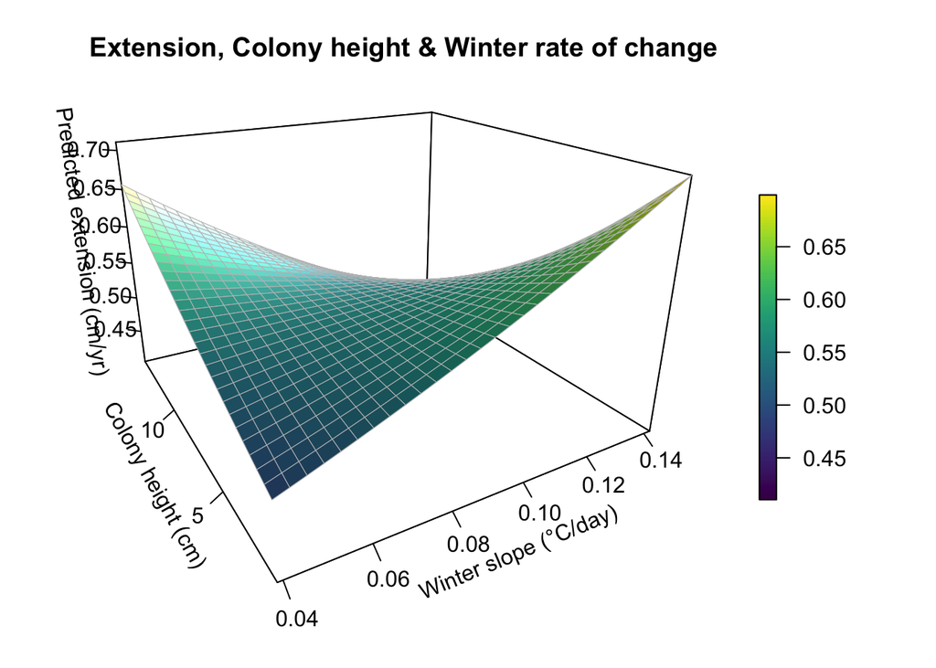

```r
library(dplyr); library(tidyr); library(tidybayes)
library(plot3D); library(viridis)

gulf_ref <- "oman"  # label
mu_winSlope <- mean(testex$winSlope, na.rm = TRUE)
mu_Bheight  <- mean(testex$Bheight,  na.rm = TRUE)

x_seq <- seq(min(testex$winSlope, na.rm=TRUE),
             max(testex$winSlope, na.rm=TRUE), length.out = 30)
y_seq <- seq(min(testex$Bheight,  na.rm=TRUE),
             max(testex$Bheight,  na.rm=TRUE), length.out = 30)

grid3D <- tidyr::crossing(
  winSlope = x_seq,
  Bheight  = y_seq
) %>%
  mutate(
    winSlope_c = winSlope - mu_winSlope,
    Bheight_c  = Bheight - mu_Bheight,
    WtavR_zg   = 0,
    gulf       = gulf_ref
  )

grid_pred <- grid3D %>%
  tidybayes::add_epred_draws(final_main, re_formula = NA) %>%
  group_by(winSlope, Bheight) %>%
  summarise(pred = mean(.epred), .groups = "drop")

zmat <- grid_pred %>%
  arrange(winSlope, Bheight) %>%
  pivot_wider(names_from = Bheight, values_from = pred) %>%
  arrange(winSlope) %>%
  select(-winSlope) %>%
  as.matrix()

par(mar = c(2.5, 2.5, 3.5, 4.5))
persp3D(
  x = x_seq, y = y_seq, z = zmat,
  colvar = zmat, col = viridis(120),
  facets = TRUE, border = "grey75", lwd = 0.5,
  contour = list(col = "grey60", nlevels = 10, side = 1),
  box = TRUE, axes = TRUE, ticktype = "detailed",
  theta = -30, phi = 22, expand = 0.65,
  shade = 0.3, lighting = TRUE, ltheta = 90, lphi = 50,
  xlab = "Winter slope (°C/day)",
  ylab = "Colony height (cm)",
  zlab = "Predicted extension (cm/yr)",
  main = "Extension, Colony height & Winter rate of change",
  colkey = list(length = 0.6, width = 0.6)
)
```

This can also be shown in 2D form (which is probably more practical, but does not look as cool):

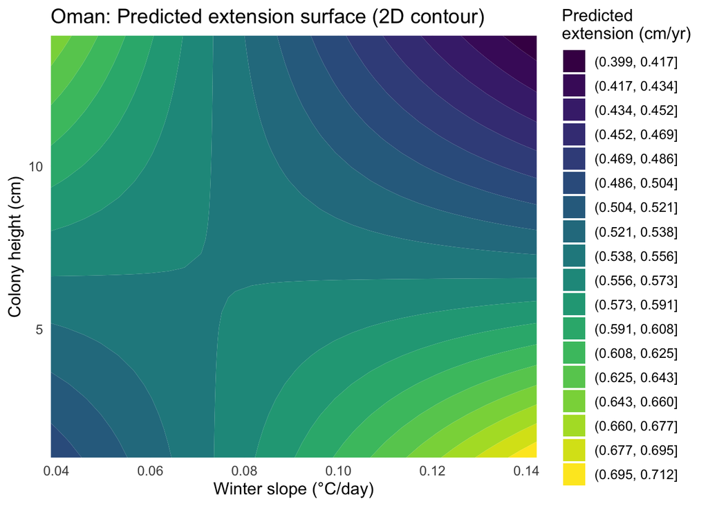

```r
library(dplyr); library(tidyr); library(tidybayes)
library(ggplot2); library(viridis)

gulf_ref <- "oman"
mu_winSlope <- mean(testex$winSlope, na.rm = TRUE)
mu_Bheight  <- mean(testex$Bheight,  na.rm = TRUE)

x_seq <- seq(min(testex$winSlope, na.rm=TRUE),
             max(testex$winSlope, na.rm=TRUE), length.out = 30)
y_seq <- seq(min(testex$Bheight,  na.rm=TRUE),
             max(testex$Bheight,  na.rm=TRUE), length.out = 30)

grid2D <- tidyr::crossing(
  winSlope = x_seq,
  Bheight  = y_seq
) %>%
  mutate(
    winSlope_c = winSlope - mu_winSlope,
    Bheight_c  = Bheight - mu_Bheight,
    WtavR_zg   = 0,
    gulf       = gulf_ref
  )

grid_pred <- grid2D %>%
  tidybayes::add_epred_draws(final_main, re_formula = NA) %>%
  group_by(winSlope, Bheight) %>%
  summarise(pred = mean(.epred), .groups = "drop")

# --- 2D contour plot ---
ggplot(grid_pred, aes(x = winSlope, y = Bheight, z = pred)) +
  geom_contour_filled(bins = 20, show.legend = TRUE) +
  scale_fill_viridis_d(option = "D", name = "Predicted\nextension (cm/yr)") +
  labs(
    x = "Winter slope (°C/day)",
    y = "Colony height (cm)",
    title = "Oman: Predicted extension surface (2D contour)"
  ) +
  theme_minimal(base_size = 12) +
  coord_cartesian(expand = FALSE)
```

These results suggest the small colonies and large colonies have different responses to the change from winter to summer.

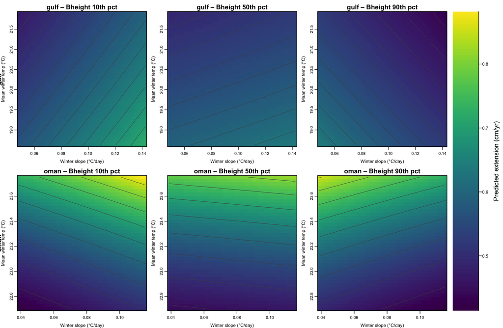

```r
suppressPackageStartupMessages({
  library(dplyr); library(tidyr); library(tidybayes)
  library(viridis); library(plot3D)
})

stopifnot(exists("final_main"), exists("testex"))

# --- Config ---
gulf_rows <- c("gulf", "oman")   # top row (gulf), bottom row (oman)
grid_nx <- 40; grid_ny <- 40
pal <- viridis(120)
pal_fun <- grDevices::colorRampPalette(pal)   # for legend gradient

# --- Height percentiles (overall) ---
bh_q    <- stats::quantile(testex$Bheight, probs = c(0.10, 0.50, 0.90), na.rm = TRUE)
bh_vals <- as.numeric(bh_q)
bh_labs <- c("10th pct","50th pct","90th pct")

# --- Model centering refs ---
mu_winSlope <- mean(testex$winSlope, na.rm = TRUE)
mu_Bheight  <- mean(testex$Bheight,  na.rm = TRUE)

# --- Per-gulf ranges + z-score refs ---
gulf_stats <- testex %>%
  mutate(gulf = as.character(gulf)) %>%
  group_by(gulf) %>%
  summarise(
    min_win = min(winSlope, na.rm = TRUE),
    max_win = max(winSlope, na.rm = TRUE),
    min_W   = min(WtavR,   na.rm = TRUE),
    max_W   = max(WtavR,   na.rm = TRUE),
    mean_W  = mean(WtavR,  na.rm = TRUE),
    sd_W    = sd(WtavR,    na.rm = TRUE),
    .groups = "drop"
  )

get_gulf_row <- function(gs, g) {
  row <- gs %>% dplyr::filter(.data$gulf == g)
  if (nrow(row) == 0) stop("Gulf not found: ", g)
  row[1, , drop = FALSE]
}

# --- One panel ---
panel_pred <- function(gulf_name, Bheight_fix) {
  gs  <- get_gulf_row(gulf_stats, gulf_name)
  sdW <- ifelse(is.na(gs$sd_W) || gs$sd_W == 0, 1e-9, gs$sd_W)

  x_seq <- seq(gs$min_win, gs$max_win, length.out = grid_nx)  # Winter slope
  y_seq <- seq(gs$min_W,   gs$max_W,   length.out = grid_ny)  # Mean winter temp

  nd <- tidyr::crossing(winSlope = x_seq, WtavR = y_seq) %>%
    mutate(
      gulf       = gulf_name,
      winSlope_c = winSlope - mu_winSlope,
      Bheight_c  = Bheight_fix - mu_Bheight,
      WtavR_zg   = (WtavR - gs$mean_W) / sdW
    )

  pred <- nd %>%
    tidybayes::add_epred_draws(final_main, re_formula = NA) %>%
    group_by(winSlope, WtavR) %>%
    summarise(epred = mean(.epred), .groups = "drop") %>%
    arrange(winSlope, WtavR)

  zmat <- pred %>%
    tidyr::pivot_wider(names_from = WtavR, values_from = epred) %>%
    arrange(winSlope) %>%
    select(-winSlope) %>%
    as.matrix()

  list(x_seq = x_seq, y_seq = y_seq, zmat = zmat)
}

# --- Build panels + shared z-limits ---
panels <- list()
for (g in gulf_rows) for (j in seq_along(bh_vals))
  panels[[paste(g, j, sep = "_")]] <- panel_pred(g, bh_vals[j])

zlim_shared <- range(unlist(lapply(panels, function(p) p$zmat)), na.rm = TRUE)

# =======================
# Draw inline (current device)
# =======================
graphics::par(oma = c(0,0,0,0))
graphics::layout(
  rbind(c(1, 2, 3, 7),
        c(4, 5, 6, 7)),
  widths  = c(1, 1, 1, 0.35),   # legend column
  heights = c(1, 1)
)

# Tight panel margins
op <- graphics::par(
  mar  = c(3.0, 3.0, 2.0, 0.6),
  mgp  = c(2.0, 0.6, 0),
  xaxs = "i", yaxs = "i"
)

# ---- Six heatmaps ----
for (row_g in gulf_rows) {
  for (col_j in seq_along(bh_vals)) {
    p <- panels[[paste(row_g, col_j, sep = "_")]]
    x_seq <- p$x_seq; y_seq <- p$y_seq; zmat <- p$zmat

    plot3D::image2D(
      x = x_seq, y = y_seq, z = zmat,
      col = pal, zlim = zlim_shared,
      xlab = "Winter slope (°C/day)",
      ylab = "Mean winter temp (°C)",
      cex.lab = 0.95, cex.axis = 0.85,
      colkey = FALSE
    )
    graphics::contour(
      x = x_seq, y = y_seq, z = zmat,
      add = TRUE, drawlabels = FALSE,
      nlevels = 10, col = "grey30", lwd = 0.7
    )

    graphics::mtext(paste0(row_g, " – Bheight ", bh_labs[col_j]),
                    side = 3, line = 0.2, cex = 0.9, font = 2)
    if (col_j == 1)
      graphics::mtext(row_g, side = 2, line = 2.6, cex = 0.9, font = 2)
  }
}

# ---- Legend cell (rightmost column) ----
graphics::par(mar = c(3, 0.4, 2, 4.2), xaxs = "i", yaxs = "i")
graphics::plot.new()
graphics::plot.window(xlim = c(0, 1), ylim = zlim_shared)

nbar  <- 500
yvals <- seq(zlim_shared[1], zlim_shared[2], length.out = nbar + 1)
cols  <- pal_fun(nbar)
for (i in seq_len(nbar)) rect(0, yvals[i], 1, yvals[i + 1], col = cols[i], border = NA)

ticks <- pretty(zlim_shared, n = 6)
axis(4, at = ticks, labels = format(ticks, digits = 3), las = 1, cex.axis = 0.9)
mtext("Predicted extension (cm/yr)", side = 4, line = 2.6, cex = 0.9)
```

```r
# Reset par/layout
graphics::par(op)
graphics::layout(1)
```